# Summarization: T5

Andrew Fogarty

7/18/2020

```r
# load python
library(reticulate)
use_condaenv("my_ml")
```

```python
# load packages
import numpy as np
import pandas as pd
import torch
import torch.nn.functional as F
from torch.utils.data import Dataset, DataLoader, RandomSampler, SequentialSampler
from collections import Counter
from transformers import T5Tokenizer, T5ForConditionalGeneration, AdamW
from torch.utils.data import TensorDataset, random_split, DataLoader, RandomSampler, SequentialSampler
import time, os, datetime, random, re
from transformers import get_linear_schedule_with_warmup
from torch.cuda.amp import autocast, GradScaler
import matplotlib.pyplot as plt
import seaborn as sns
import torch.nn as nn
import nlp

torch.cuda.amp.autocast(enabled=True)
```

```
## <torch.cuda.amp.autocast_mode.autocast object at 0x0000000032777CC8>
```

```python
SEED = 15
random.seed(SEED)
np.random.seed(SEED)
torch.manual_seed(SEED)
```

```
## <torch._C.Generator object at 0x00000000227F8530>
```

```python
torch.backends.cudnn.deterministic = True

# tell pytorch to use cuda
device = torch.device("cuda")
```

# 1 Introduction

There are two types of summaries: (1) abstractive, or explaining in your own words, and (2) extractive, or building a summary from existing text. Humans are mostly abstractive while NLP systems are mostly extractive. In this guide we use T5, a pre-trained and very large (e.g., roughly twice the size of BERT-base) encoder-decoder Transformer model. T5, a model devised by Google, is an important advancement in the field of Transformers because it achieves near human-level performance on a variety of benchmarks like GLUE and SQuAD.

The guide proceeds by (1) preparing the data for text summarization with T5 small – a small version of T5 base, and (2) training the data in PyTorch.

## 1.1 Data Preparation

Some unique pre-processing is required when using T5 for summarization. Specifically, we need to add “summarize:” to the beginning of all of our text that needs to be summarized and we need shift our summaries rightward by one token which we do by adding “<pad” to the beginning of each summary. T5’s tokenizer in the `transformers` library will handle the details from there.

```python
# prepare and load data
def prepare_df(pkl_location):
    # read pkl as pandas
    df = pd.read_pickle(pkl_location)
    # just keep us/kabul labels
    df = df.loc[(df['target'] == 'US') | (df['target'] == 'Kabul')]
    # mask DV to recode
    us = df['target'] == 'US'
    kabul = df['target'] == 'Kabul'
    # apply mask
    df.loc[us, 'target'] = 1
    df.loc[kabul, 'target'] = 0
    # reset index
    df = df.reset_index(drop=True)
    return df


# load df
df = prepare_df('C:\\Users\\Andrew\\Desktop\\df.pkl')


# prepare data
def clean_df(df):
    # strip dash but keep a space
    df['body'] = df['body'].str.replace('-', ' ')
    # lower case the data
    df['body'] = df['body'].apply(lambda x: x.lower())
    # remove excess spaces near punctuation
    df['body'] = df['body'].apply(lambda x: re.sub(r'\s([?.!"](?:\s|$))', r'\1', x))
    # generate a word count for body
    df['word_count'] = df['body'].apply(lambda x: len(x.split()))
    # generate a word count for summary
    df['word_count_summary'] = df['title_osc'].apply(lambda x: len(x.split()))
    # remove excess white spaces
    df['body'] = df['body'].apply(lambda x: " ".join(x.split()))
    # lower case to body
    df['body'] = df['body'].apply(lambda x: x.lower())
    # lower case to summary
    df['title_osc'] = df['title_osc'].apply(lambda x: x.lower())
    # add summarize akin to T5 setup
    df['body'] = 'summarize: ' + df['body']
    # add pad token to summaries
    df['title_osc'] = '<pad>' + df['title_osc']
    # add " </s>" to end of body
    df['body'] = df['body'] + " </s>"
    # add " </s>" to end of review
    df['title_osc'] = df['title_osc'] + " </s>"
    return df


# clean df
df = clean_df(df)
```

## 1.2 Instantiate Tokenizer

Next, we instantiate the T5 tokenizer from `transformers` and check some special token IDs.

```python
# instantiate T5 tokenizer
tokenizer = T5Tokenizer.from_pretrained('t5-small')

# check token ids
tokenizer.eos_token_id
```

```
## 1
```

```python
tokenizer.bos_token_id
tokenizer.unk_token_id
```

```
## 2
```

```python
tokenizer.pad_token_id
```

```
## 0
```

## 1.3 Tokenize the Corpus

Then, we proceed to tokenize our corpus like usual. Notice that we effectively do this process twice as we tokenize our corpus and also tokenize our summaries.

```python
# tokenize the main text
def tokenize_corpus(df, tokenizer, max_len):
    # token ID storage
    input_ids = []
    # attension mask storage
    attention_masks = []
    # max len -- 512 is max
    max_len = max_len
    # for every document:
    for doc in df:
        # `encode_plus` will:
        #   (1) Tokenize the sentence.
        #   (2) Prepend the `[CLS]` token to the start.
        #   (3) Append the `[SEP]` token to the end.
        #   (4) Map tokens to their IDs.
        #   (5) Pad or truncate the sentence to `max_length`
        #   (6) Create attention masks for [PAD] tokens.
        encoded_dict = tokenizer.encode_plus(
                            doc,  # document to encode.
                            add_special_tokens=True,  # add tokens relative to model
                            max_length=max_len,  # set max length
                            truncation=True,  # truncate longer messages
                            pad_to_max_length=True,  # add padding
                            return_attention_mask=True,  # create attn. masks
                            return_tensors='pt'  # return pytorch tensors
                       )

        # add the tokenized sentence to the list
        input_ids.append(encoded_dict['input_ids'])

        # and its attention mask (differentiates padding from non-padding)
        attention_masks.append(encoded_dict['attention_mask'])

    return torch.cat(input_ids, dim=0), torch.cat(attention_masks, dim=0)


# create tokenized data
body_input_ids, body_attention_masks = tokenize_corpus(df['body'].values, tokenizer, 512)



# how long are tokenized summaries
ls = []
for i in range(df.shape[0]):
    ls.append(len(tokenizer.tokenize(df.iloc[i]['title_osc'])))

temp_df = pd.DataFrame({'len_tokens': ls})
temp_df['len_tokens'].mean()  # 19
```

```
## 19.956993529118964
```

```python
temp_df['len_tokens'].median()  # 20
```

```
## 20.0
```

```python
temp_df['len_tokens'].max()  # 44
```

```
## 44
```

```python
temp_df.quantile(0.99)  # 30

# create tokenized summaries
```

```
## len_tokens    30.0
## Name: 0.99, dtype: float64
```

```python
summary_input_ids, summary_attention_masks = tokenize_corpus(df['title_osc'].values, tokenizer, 30)
```

## 1.4 Prepare and Split Data

Next, we split our data into train, validation, and test sets.

```python
# prepare tensor data sets
def prepare_dataset(body_tokens, body_masks, summary_token, summary_masks):
    # create tensor data sets
    tensor_df = TensorDataset(body_tokens, body_masks, summary_token, summary_masks)
    # 80% of df
    train_size = int(0.8 * len(df))
    # 20% of df
    val_size = len(df) - train_size
    # 50% of validation
    test_size = int(val_size - 0.5*val_size)
    # divide the dataset by randomly selecting samples
    train_dataset, val_dataset = random_split(tensor_df, [train_size, val_size])
    # divide validation by randomly selecting samples
    val_dataset, test_dataset = random_split(val_dataset, [test_size, test_size+1])

    return train_dataset, val_dataset, test_dataset


# create tensor data sets
train_dataset, val_dataset, test_dataset = prepare_dataset(body_input_ids,
                                                           body_attention_masks,
                                                           summary_input_ids,
                                                           summary_attention_masks
                                                           )
```

## 1.5 Instantiate Training Models

Now we are ready to prepare our training scripts which follow the other guides closely. `T5ForConditionalGeneration` asks that we supply three inputs into the model’s `forward` function: (1) corpus token ids, (2) corpus attention masks, and (3) our shifted summary tokens (labels).

```python
def train(model, dataloader, optimizer):

    # capture time
    total_t0 = time.time()

    # Perform one full pass over the training set.
    print("")
    print('======== Epoch {:} / {:} ========'.format(epoch + 1, epochs))
    print('Training...')

    # reset total loss for epoch
    train_total_loss = 0
    total_train_f1 = 0

    # put model into traning mode
    model.train()

    # for each batch of training data...
    for step, batch in enumerate(dataloader):

        # progress update every 40 batches.
        if step % 40 == 0 and not step == 0:

            # Report progress.
            print('  Batch {:>5,}  of  {:>5,}.'.format(step, len(dataloader)))

        # Unpack this training batch from our dataloader:
        #
        # As we unpack the batch, we'll also copy each tensor to the GPU using
        # the `to` method.
        #
        # `batch` contains three pytorch tensors:
        #   [0]: input tokens
        #   [1]: attention masks
        #   [2]: summary tokens
        b_input_ids = batch[0].cuda()
        b_input_mask = batch[1].cuda()
        b_summary_ids = batch[2].cuda()
        b_summary_mask = batch[3].cuda()

        # clear previously calculated gradients
        optimizer.zero_grad()

        # runs the forward pass with autocasting.
        with autocast():
            # forward propagation (evaluate model on training batch)
            outputs = model(input_ids=b_input_ids,
                                 attention_mask=b_input_mask,
                                 labels=b_summary_ids,
                                 decoder_attention_mask=b_summary_mask)

            loss, prediction_scores = outputs[:2]

            # sum the training loss over all batches for average loss at end
            # loss is a tensor containing a single value
            train_total_loss += loss.item()

        # Scales loss.  Calls backward() on scaled loss to create scaled gradients.
        # Backward passes under autocast are not recommended.
        # Backward ops run in the same dtype autocast chose for corresponding forward ops.
        scaler.scale(loss).backward()

        # scaler.step() first unscales the gradients of the optimizer's assigned params.
        # If these gradients do not contain infs or NaNs, optimizer.step() is then called,
        # otherwise, optimizer.step() is skipped.
        scaler.step(optimizer)

        # Updates the scale for next iteration.
        scaler.update()

        # update the learning rate
        scheduler.step()

    # calculate the average loss over all of the batches
    avg_train_loss = train_total_loss / len(dataloader)

    # Record all statistics from this epoch.
    training_stats.append(
        {
            'Train Loss': avg_train_loss
        }
    )

    # training time end
    training_time = format_time(time.time() - total_t0)

    # print result summaries
    print("")
    print("summary results")
    print("epoch | trn loss | trn time ")
    print(f"{epoch+1:5d} | {avg_train_loss:.5f} | {training_time:}")

    return training_stats


def validating(model, dataloader):

    # capture validation time
    total_t0 = time.time()

    # After the completion of each training epoch, measure our performance on
    # our validation set.
    print("")
    print("Running Validation...")

    # put the model in evaluation mode
    model.eval()

    # track variables
    total_valid_loss = 0

    # evaluate data for one epoch
    for batch in dataloader:

        # Unpack this training batch from our dataloader:
        # `batch` contains three pytorch tensors:
        #   [0]: input tokens
        #   [1]: attention masks
        #   [2]: summary tokens
        b_input_ids = batch[0].cuda()
        b_input_mask = batch[1].cuda()
        b_summary_ids = batch[2].cuda()
        b_summary_mask = batch[3].cuda()

        # tell pytorch not to bother calculating gradients
        # as its only necessary for training
        with torch.no_grad():

            # forward propagation (evaluate model on training batch)
            outputs = model(input_ids=b_input_ids,
                                 attention_mask=b_input_mask,
                                 labels=b_summary_ids,
                                 decoder_attention_mask=b_summary_mask)

            loss, prediction_scores = outputs[:2]

            # sum the training loss over all batches for average loss at end
            # loss is a tensor containing a single value
            total_valid_loss += loss.item()

    # calculate the average loss over all of the batches.
    global avg_val_loss
    avg_val_loss = total_valid_loss / len(dataloader)

    # Record all statistics from this epoch.
    valid_stats.append(
        {
            'Val Loss': avg_val_loss,
            'Val PPL.': np.exp(avg_val_loss)
        }
    )

    # capture end validation time
    training_time = format_time(time.time() - total_t0)

    # print result summaries
    print("")
    print("summary results")
    print("epoch | val loss | val ppl | val time")
    print(f"{epoch+1:5d} | {avg_val_loss:.5f} | {np.exp(avg_val_loss):.3f} | {training_time:}")

    return valid_stats


def testing(model, dataloader):

    print("")
    print("Running Testing...")

    # measure training time
    t0 = time.time()

    # put the model in evaluation mode
    model.eval()

    # track variables
    total_test_loss = 0
    predictions = []
    actuals = []

    # evaluate data for one epoch
    for step, batch in enumerate(dataloader):
        # progress update every 40 batches.
        if step % 40 == 0 and not step == 0:
            # Calculate elapsed time in minutes.
            elapsed = format_time(time.time() - t0)
            # Report progress.
            print('  Batch {:>5,}  of  {:>5,}.    Elapsed: {:}.'.format(step, len(dataloader), elapsed))

        # Unpack this training batch from our dataloader:
        # `batch` contains three pytorch tensors:
        #   [0]: input tokens
        #   [1]: attention masks
        #   [2]: summary tokens
        b_input_ids = batch[0].cuda()  # batch size, length
        b_input_mask = batch[1].cuda()  # batch size, length
        b_summary_ids = batch[2].cuda()  # batch size, length
        b_summary_mask = batch[3].cuda()

        # tell pytorch not to bother calculating gradients
        # as its only necessary for training
        with torch.no_grad():

            # forward propagation (evaluate model on training batch)
            outputs = model(input_ids=b_input_ids,
                                 attention_mask=b_input_mask,
                                 labels=b_summary_ids,
                                 decoder_attention_mask=b_summary_mask)

            loss, prediction_scores = outputs[:2]

            total_test_loss += loss.item()

            generated_ids = model.generate(
                    input_ids=b_input_ids,
                    attention_mask=b_input_mask,
                    do_sample=True,  # add some random sampling
                    temperature=0.8,  # sharper conditional next distribution
                    top_k=45,  # k most likely next words
                    top_p=0.9,  # smallest set of cum. prob exceed p for k
                    max_length=18,  # slightly longer
                    min_length=14,  # dont eos before reaching
                    num_beams=1,  # not using beam
                    repetition_penalty=2.5,
                    length_penalty=2.5,
                    early_stopping=False,  # for use with beam
                    use_cache=True,
                    num_return_sequences=1
                    )

            preds = [tokenizer.decode(g, skip_special_tokens=True, clean_up_tokenization_spaces=True) for g in generated_ids]
            target = [tokenizer.decode(t, skip_special_tokens=True, clean_up_tokenization_spaces=True)for t in b_summary_ids]
            predictions.extend(preds)
            actuals.extend(target)

    # calculate the average loss over all of the batches.
    avg_test_loss = total_test_loss / len(dataloader)

    # Record all statistics from this epoch.
    test_stats.append(
        {
            'Test Loss': avg_test_loss,
            'Test PPL.': np.exp(avg_test_loss),
        }
    )
    global df2
    temp_data = pd.DataFrame({'predicted': predictions, 'actual': actuals})
    df2 = df2.append(temp_data)

    return test_stats


# time function
def format_time(elapsed):
    '''
    Takes a time in seconds and returns a string hh:mm:ss
    '''
    # Round to the nearest second.
    elapsed_rounded = int(round((elapsed)))
    # Format as hh:mm:ss
    return str(datetime.timedelta(seconds=elapsed_rounded))
```

Before training, several prepatory objects are instantiated like the model, data loaders, and the optimizer.

## 1.6 Prepare for Training

```python
# instantiate model T5 transformer with a language modeling head on top
model = T5ForConditionalGeneration.from_pretrained('t5-small').cuda()  # to GPU


# create the DataLoaders
```

[output not shown]

```python
train_dataloader = DataLoader(dataset=train_dataset,
                              shuffle=True,
                              batch_size=16
                              )

valid_dataloader = DataLoader(dataset=val_dataset,
                              shuffle=False,
                              batch_size=16
                              )

test_dataloader = DataLoader(dataset=test_dataset,
                             shuffle=False,
                             batch_size=16
                             )


# Adam w/ Weight Decay Fix
# set to optimizer_grouped_parameters or model.parameters()
optimizer = AdamW(model.parameters(),
                  lr = 3e-5
                  )

# epochs
epochs = 6

# lr scheduler
total_steps = len(train_dataloader) * epochs
scheduler = get_linear_schedule_with_warmup(optimizer,
                                            num_warmup_steps=0,
                                            num_training_steps=total_steps)

# create gradient scaler for mixed precision
scaler = GradScaler()
```

## 1.7 Train and Validate

Finally we are ready to train. Two containers are created to store the results of each training and validation epoch

```python
# create training result storage
training_stats = []
valid_stats = []
best_valid_loss = float('inf')

# for each epoch
for epoch in range(epochs):
    # train
    train(model, train_dataloader, optimizer)
    # validate
    validating(model, valid_dataloader)
    # check validation loss
    if valid_stats[epoch]['Val Loss'] < best_valid_loss:
        best_valid_loss = valid_stats[epoch]['Val Loss']
        # save best model for use later
        torch.save(model.state_dict(), 't5-summary.pt')  # torch save
        model_to_save = model.module if hasattr(model, 'module') else model
        model_to_save.save_pretrained('./model_save/t5/')  # transformers save
        tokenizer.save_pretrained('./model_save/t5/')  # transformers save
```

```
##
## ======== Epoch 1 / 6 ========
## Training...
##   Batch    40  of    503.
##   Batch    80  of    503.
##   Batch   120  of    503.
##   Batch   160  of    503.
##   Batch   200  of    503.
##   Batch   240  of    503.
##   Batch   280  of    503.
##   Batch   320  of    503.
##   Batch   360  of    503.
##   Batch   400  of    503.
##   Batch   440  of    503.
##   Batch   480  of    503.
##
## summary results
## epoch | trn loss | trn time
##     1 | 1.89592 | 0:01:48
## [{'Train Loss': 1.8959172396489214}]
##
## Running Validation...
##
## summary results
## epoch | val loss | val ppl | val time
##     1 | 1.01534 | 2.760 | 0:00:06
## [{'Val Loss': 1.0153419432185946, 'Val PPL.': 2.7603071043155514}]
## ('./model_save/t5/spiece.model', './model_save/t5/special_tokens_map.json', './model_save/t5/added_tokens.json')
##
## ======== Epoch 2 / 6 ========
## Training...
##   Batch    40  of    503.
##   Batch    80  of    503.
##   Batch   120  of    503.
##   Batch   160  of    503.
##   Batch   200  of    503.
##   Batch   240  of    503.
##   Batch   280  of    503.
##   Batch   320  of    503.
##   Batch   360  of    503.
```

[output cut: 114 more lines]

```
##   Batch   480  of    503.
##
## summary results
## epoch | trn loss | trn time
##     6 | 0.95984 | 0:01:43
## [{'Train Loss': 1.8959172396489214}, {'Train Loss': 1.1477415556936092}, {'Train Loss': 1.0506925011723938}, {'Train Loss': 1.0019760210637307}, {'Train Loss': 0.9725703113595724}, {'Train Loss': 0.9598354040746897}]
##
## Running Validation...
##
## summary results
## epoch | val loss | val ppl | val time
##     6 | 0.82165 | 2.274 | 0:00:05
## [{'Val Loss': 1.0153419432185946, 'Val PPL.': 2.7603071043155514}, {'Val Loss': 0.9160231162631323, 'Val PPL.': 2.499331050487102}, {'Val Loss': 0.8682786538487389, 'Val PPL.': 2.3828056879323003}, {'Val Loss': 0.8386138081550598, 'Val PPL.': 2.3131582722218367}, {'Val Loss': 0.8272512039494893, …
## ('./model_save/t5/spiece.model', './model_save/t5/special_tokens_map.json', './model_save/t5/added_tokens.json')
##
```

Now we can present our training results nicely in a data frame.

```python
# organize results
pd.set_option('precision', 3)
df_train_stats = pd.DataFrame(data=training_stats)
df_valid_stats = pd.DataFrame(data=valid_stats)
df_stats = pd.concat([df_train_stats, df_valid_stats], axis=1)
df_stats.insert(0, 'Epoch', range(1, len(df_stats)+1))
df_stats = df_stats.set_index('Epoch')
df_stats
```

```
##        Train Loss  Val Loss  Val PPL.
## Epoch
## 1           1.896     1.015     2.760
## 2           1.148     0.916     2.499
## 3           1.051     0.868     2.383
## 4           1.002     0.839     2.313
## 5           0.973     0.827     2.287
## 6           0.960     0.822     2.274
```

We also plot out training results:

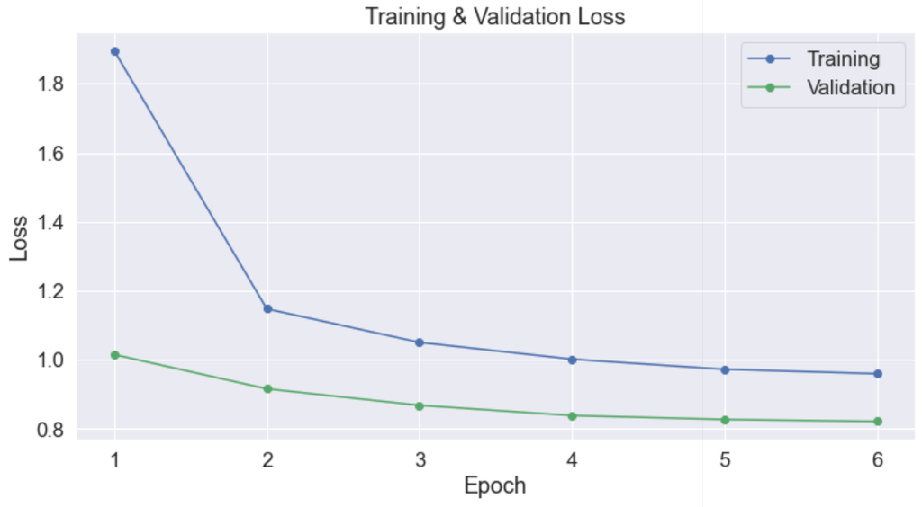

Training Results

```python
# plot results
def plot_results(df):
    # styling from seaborn.
    sns.set(style='darkgrid')
    # uncrease the plot size and font size.
    sns.set(font_scale=1.5)
    plt.rcParams["figure.figsize"] = (12,6)

    # plot the learning curve.
    plt.plot(df_stats['Train Loss'], 'b-o', label="Training")
    plt.plot(df_stats['Val Loss'], 'g-o', label="Validation")

    # Label the plot.
    plt.title("Training & Validation Loss")
    plt.xlabel("Epoch")
    plt.ylabel("Loss")
    plt.legend()
    plt.xticks(list(range(1, epochs+1)))
    return plt.show()


plot_results(df_stats)
```

## 1.8 Test and Generate Summaries

While also checking our loss in our held-out test data, we also generate predicted summaries to compare with our actual summaries so we can evaluate it by ROGUE metrics.

```python
# test the model
df2 = pd.DataFrame({'predicted': [], 'actual': []})
test_stats = []
model.load_state_dict(torch.load('t5-summary.pt'))
```

```
## <All keys matched successfully>
```

```python
testing(model, test_dataloader)
```

```
##
## Running Testing...
##   Batch    40  of     63.    Elapsed: 0:00:53.
## [{'Test Loss': 0.8548792009315793, 'Test PPL.': 2.351090353895645}]
```

```python
print(df2.head(5))
```

```
##                                            predicted                                             actual
## 0  afghan taliban commentary questions us's willi...  afghan taliban commentary no other options but...
## 1  taliban say six soldiers killed in attack on p...  taliban say posts captured six soldiers killed...
## 2  taliban say two soldiers killed in blast in af...  taliban report two army soldiers killed in bla...
## 3  taliban say four soldiers killed in attack in ...  taliban say four afghan soldiers killed in wes...
## 4  taliban say two soldiers killed three wounded ...  taliban say two soldiers killed three injured ...
```

## 1.9 ROUGE Metrics

Evaluating summarization tasks are hard to measure and tune for as there are many criteria:

1. Information satisfaction (answer query)
2. Coverage (summarize corpus)
3. Fluency (sounds natural)
4. Concision (not redundant, no fluff)

In *BLEU*, we are about precision: how many n-grams in the candidate are in the reference translation? In *ROGUE*, we care about recall: how many n-grams in the reference summaries are in the candidate?

```python
# ROUGE
nlp_rouge = nlp.load_metric('rouge')

scores = nlp_rouge.compute(
    df2.predicted.to_list(), df2.actual.to_list(),
    rouge_types=['rouge1', 'rouge2', 'rougeL', 'rougeLsum'],
    use_agregator=True, use_stemmer=False
)

df = pd.DataFrame({
    'rouge1': [scores['rouge1'].mid.precision, scores['rouge1'].mid.recall, scores['rouge1'].mid.fmeasure],
    'rouge2': [scores['rouge2'].mid.precision, scores['rouge2'].mid.recall, scores['rouge2'].mid.fmeasure],
    'rougeL': [scores['rougeL'].mid.precision, scores['rougeL'].mid.recall, scores['rougeL'].mid.fmeasure]}, index=[ 'P', 'R', 'F'])

df.style.format({'rouge1': "{:.4f}", 'rouge2': "{:.4f}", 'rougeL': "{:.4f}"})
```

```
## <pandas.io.formats.style.Styler object at 0x0000000064A2DDC8>
```

We interpret the metrics below as follows:

- ROUGE Recall: x% means that x% of the n-grams in the reference summary are also present in the generated summary.
- ROUGE Precision: x% means that x% of the n-grams in the generated summary are also present in the reference summary.
- ROUGE F1: like any F1-score.

```python
# show df
print(df)
```

```
##    rouge1  rouge2  rougeL
## P   0.538   0.310   0.513
## R   0.497   0.290   0.475
## F   0.512   0.297   0.489
```

# 2 Sources

- Raffel, Colin, Noam Shazeer, Adam Roberts, Katherine Lee, Sharan Narang, Michael Matena, Yanqi Zhou, Wei Li, and Peter J. Liu. “Exploring the limits of transfer learning with a unified text-to-text transformer.” arXiv preprint arXiv:1910.10683 (2019).